# R Data Manipulation with data.table

# Read Data

## Pull Data from REDCap

- Pull data from REDCap using API and save the csv file

```r
api_token       <- '1245456abcdef'
api_url         <- 'https://redcap_url/api/'
csv_file <- RCurl::postForm(
  api_url
  , token=api_token
  , content='record'
  , format='csv'
  , type='flat'
  , .opts=curlOptions(ssl.verifypeer=FALSE)
)
write(csv_file, file='../csv/filename.csv')
```

## Pull Data from MySQL

```r
library(RMySQL)
con <- dbConnect(RMySQL::MySQL()
                ,user="username"
                ,password="password"
                ,dbname="information_db"
                ,host="1.1.1.1"
                ,port=3306)
table_columns <- dbGetQuery(con
                           ,"select *
                               from COLUMNS
                               ")
on.exit(RMySQL::dbDisconnect(con))
```

## Read Data from SAS/SPSS

```r
library(foreign)
## dt <- read.spss("filename",to.data.frame = TRUE)
library(haven)
## dt <- read_sas(data_file = "filename")
```

# General Data Description

- Create a HTML file the describe all variables in a dataset

```r
Wu::sv_desc(dt, file_name = "dt_variables.html")
```

# Rename Variables & Revalue A Vector

- match function matches the first vector to the second vector, gives the indexes of elements from vector one that matched in vector two
- dplyr::rename function renames variable names

```r
library(Wu)

match(1:5, c(4, 2)) %>% prt()
```

| x |
| --- |
| NA |
| 2 |
| NA |
| 1 |
| NA |

```r
dt <- data.table(A=1:3, B=2:4)
colnames(dt) %>% prt(caption = "Original Column Names")
```

Original Column Names

| x |
| --- |
| A |
| B |

```r
colnames(dt) <- plyr::revalue(colnames(dt), c("A"="Variable_A"))
colnames(dt) %>% prt(caption = "Column Names Changed")
```

Column Names Changed

| x |
| --- |
| Variable_A |
| B |

```r
## dplyr::rename(dt, var_b=B)


lst <- list("A"="Variable_A")
## names(lst)
## unlist(lst)

colnames(dt)[colnames(dt) %in% names(lst)] <- unlist(lst)[colnames(dt)[colnames(dt) %in% names(lst)]]



v <- c("A", "B", "C")
lst <- c(
    "A"="A-"
  , "B"
  , "C"="C+"
)

plyr::revalue(v, lst) %>% prt(caption = "plyr::revalue function")
```

plyr::revalue function

| x |
| --- |
| A- |
| B |
| C+ |

```r
## names(lst)

v[v %in% names(lst)] <- unlist(lst)[v[v %in% names(lst)]]

v %>% prt()
```

| x |
| --- |
| A- |
| B |
| C+ |

```r
## class(v)

dt <- data.table(var1 = 1, var2 = 2, var3 = 3)
Wu::renameVariables(obj = dt, lst = c(var1 = "varA", var2 = "varB")) %>% prt()
```

| varA | varB | var3 |
| --- | --- | --- |
| 1 | 2 | 3 |

# Regular Expression

## Find Pattern

```r
grepl("High", c(NA, "High", "Low"), fixed=FALSE)
```

[1] FALSE TRUE FALSE

# Fill Missing Values

## Replace elements in a vector by a specific value

```r
x <- 1:10
list <- c(2, 4, 9)
value <- 0

replace(x, list, value)
```

[1] 1 0 3 0 5 6 7 8 0 10

## Index of observations

```r
dt <- data.table(
    group=c("A", "A", "B", "B", "B", "C", "C", "C", "C")
  , var1=1:9
)

dt <- dt[, index_i := .I
         ][, index_n := 1:.N
           ][, index_i_group := .I, by = .(group)
             ][, index_n_group := 1:.N, by = .(group)]

dt %>% prt()
```

| group | var1 | index_i | index_n | index_i_group | index_n_group |
| --- | --- | --- | --- | --- | --- |
| A | 1 | 1 | 1 | 1 | 1 |
| A | 2 | 2 | 2 | 2 | 2 |
| B | 3 | 3 | 3 | 3 | 1 |
| B | 4 | 4 | 4 | 4 | 2 |
| B | 5 | 5 | 5 | 5 | 3 |
| C | 6 | 6 | 6 | 6 | 1 |
| C | 7 | 7 | 7 | 7 | 2 |
| C | 8 | 8 | 8 | 8 | 3 |
| C | 9 | 9 | 9 | 9 | 4 |

## Last Observation Carry Forward (LOCF)

- data.table::nafill funtion only works for numeric variables
- Workaround for character variables by filling indexes of character variables instead https://github.com/Rdatatable/data.table/issues/3992#issuecomment-546295277
- type=“nocb”: Next Observation Carry Backward
- type=“const”: fill with constant

```r
dt <- data.table(
    n1=c(1, NA, 2, NA, NA, 3, 3, NA)
  , c1=c("A", "A", "B", NA, "C", NA, NA, NA)
)


dt <- dt[
  , n1_locf := nafill(n1, type="locf")
][, c1_locf := c1[nafill(replace(.I, is.na(c1), NA), type="locf")]
  ][, index := .I]

dt[, .(index, n1, n1_locf, c1, c1_locf)] %>% prt()
```

| index | n1 | n1_locf | c1 | c1_locf |
| --- | --- | --- | --- | --- |
| 1 | 1 | 1 | A | A |
| 2 | NA | 1 | A | A |
| 3 | 2 | 2 | B | B |
| 4 | NA | 2 | NA | B |
| 5 | NA | 2 | C | C |
| 6 | 3 | 3 | NA | C |
| 7 | 3 | 3 | NA | C |
| 8 | NA | 3 | NA | C |

- More detailed process for character variables

```r
fdt2 <- fdt2[, i := .I
             ][is.na(state_daily4), i := NA
               ][, i_fill := nafill(i, type="locf"), by = .(record_id)
               ][, state_daily4_locf := state_daily4[i_fill]]
```

# Data Functions

## Sum Multiple Columns

```r
is.1 <- function(x){x %in% c(1)}
sum.1 <- function(x){sum(as.numeric(is.1(x)))}
dm <- dm[, race_sum := sum(.SD)
       , .SDcols = paste0("race___", as.character(1:6))
       , by = 1:nrow(dm)]
dm <- dm[, conditions_num := sum(is.1(hypertension)
                               , is.1(diabetes)
                               , is.1(heart_disease)
                               , is.1(renal_disease)
                               , is.1(malignancies)
                               , is.1(respiratory_disease)
                                 )
       , by = 1:nrow(dm)
         ]
```

## Rolling Average

```r
library(zoo)
dt <- data.table(series = c(1:10, NA, 11:21))
dt <- dt[, mv2 := rollmean(series, k = 2, align = "right", na.pad = TRUE)
         ][, mv3 := rollmean(series, k = 3, align = "right", na.pad = TRUE)]

dt %>% prt()
```

| series | mv2 | mv3 |
| --- | --- | --- |
| 1 | NA | NA |
| 2 | 1.5 | NA |
| 3 | 2.5 | 2 |
| 4 | 3.5 | 3 |
| 5 | 4.5 | 4 |
| 6 | 5.5 | 5 |
| 7 | 6.5 | 6 |
| 8 | 7.5 | 7 |
| 9 | 8.5 | 8 |
| 10 | 9.5 | 9 |
| NA | NA | NA |
| 11 | NA | NA |
| 12 | 11.5 | NA |
| 13 | 12.5 | 12 |
| 14 | 13.5 | 13 |
| 15 | 14.5 | 14 |
| 16 | 15.5 | 15 |
| 17 | 16.5 | 16 |
| 18 | 17.5 | 17 |
| 19 | 18.5 | 18 |
| 20 | 19.5 | 19 |
| 21 | 20.5 | 20 |

## Weighted Rolling Average

```r
dt <- data.table(series = c(1:10, NA, 11:21))

n <- 2
wts <- (1:n) / sum(1:n)
wm <- function(x){
    invisible(weighted.mean(x = x, w = wts))
}

dt <- dt[, mvw2 := frollapply(seq_len(.N)
                            , FUN = function(ind) wm(series[ind])
                            , n = 2
                            , align = "left"
                              )]

dt %>% prt()
```

| series | mvw2 |
| --- | --- |
| 1 | 1.666667 |
| 2 | 2.666667 |
| 3 | 3.666667 |
| 4 | 4.666667 |
| 5 | 5.666667 |
| 6 | 6.666667 |
| 7 | 7.666667 |
| 8 | 8.666667 |
| 9 | 9.666667 |
| 10 | NA |
| NA | NA |
| 11 | 11.666667 |
| 12 | 12.666667 |
| 13 | 13.666667 |
| 14 | 14.666667 |
| 15 | 15.666667 |
| 16 | 16.666667 |
| 17 | 17.666667 |
| 18 | 18.666667 |
| 19 | 19.666667 |
| 20 | 20.666667 |
| 21 | NA |

## Weighted Rolling Median

```r
dt <- data.table(var1 = c(1:10, NA, 11:21))

library(matrixStats)
n <- 4
wts <- c(0.1, 1, 1, 1)
wts <- wts / sum(wts)
wmd <- function(x){
    invisible(matrixStats::weightedMedian(x = x, w = wts))
}

dt <- dt[, mvwmd3 := frollapply(seq_len(.N)
                            , FUN = function(ind) wmd(var1[ind])
                            , n = 4
                            , align = "left"
                              )]

dt %>% prt()
```

| var1 | mvwmd3 |
| --- | --- |
| 1 | 2.95 |
| 2 | 3.95 |
| 3 | 4.95 |
| 4 | 5.95 |
| 5 | 6.95 |
| 6 | 7.95 |
| 7 | 8.95 |
| 8 | NA |
| 9 | NA |
| 10 | NA |
| NA | NA |
| 11 | 12.95 |
| 12 | 13.95 |
| 13 | 14.95 |
| 14 | 15.95 |
| 15 | 16.95 |
| 16 | 17.95 |
| 17 | 18.95 |
| 18 | 19.95 |
| 19 | NA |
| 20 | NA |
| 21 | NA |

## Concatenate Multiple Rows by Group

```r
dt <- data.table(a=letters[1:10],b=LETTERS[1:10],ID=c(1,1,1,2,2,2,2,3,3,3))

dt
```

a b ID 1: a A 1 2: b B 1 3: c C 1 4: d D 2 5: e E 2 6: f F 2 7: g G 2 8: h H 3 9: i I 3 10: j J 3

```r
dt[, lapply(.SD, paste0, collapse=" "), by = ID, .SD = c("a")]
```

ID a 1: 1 a b c 2: 2 d e f g 3: 3 h i j

```r
dt[, a2 := paste0(a, collapse = "-"), by = ID]
```

## Shift Column

```r
cf <- cf[
][, status_row_n_int := nafill(status_row_n, type = "locf"), by = list(mrn)
  ][, fio2_int := nafill(fio2_row_filled, type = "locf"), by = list(mrn)
    ][,  datetime_record_nx1 := shift(datetime_record, type="lead"), by = list(mrn)
      ][, time_int := as.numeric(difftime(datetime_record_nx1, datetime_record, units = "hours"))
        ]
```

## Permutate & combination

```r
expand.grid(levels(dt$sex_2.factor)
               , levels(dt$age_group)
               , levels(dt$race_ethnicity)
               , levels(dt$com_obesity)
                 )

combn(letters[1:4], 2)

perm_without_replacement <- function(n, r){
  return(factorial(n)/factorial(n - r)/ factorial(r))
}

factorial(4)
# 9 choose 3
perm_without_replacement(9, 3) * perm_without_replacement(6, 3)

6 * 5 * 4 / (3 * 2)
```

## Split data.frame

```r
split(t, seq(nrow(t)))

split(df, df$gender)
```

## Replicate Rows

```r
library(data.table)
library(Wu)
dt <- data.table(name=letters[1:4])
dt %>% prt()
```

| name |
| --- |
| a |
| b |
| c |
| d |

```r
dt <- dt[rep(1:.N, 3)][order(name)][, index := 1:.N, by = name]
dt %>% prt()
```

| name | index |
| --- | --- |
| a | 1 |
| a | 2 |
| a | 3 |
| b | 1 |
| b | 2 |
| b | 3 |
| c | 1 |
| c | 2 |
| c | 3 |
| d | 1 |
| d | 2 |
| d | 3 |

```r
dt <- data.table(
    id = 1:6
  , num = c(3, 5, 6, 3, 4, 5)
)
dt <- dt[rep(1:.N, times = num)][, sub_index := 1:.N, by = id]
dt %>% prt()
```

| id | num | sub_index |
| --- | --- | --- |
| 1 | 3 | 1 |
| 1 | 3 | 2 |
| 1 | 3 | 3 |
| 2 | 5 | 1 |
| 2 | 5 | 2 |
| 2 | 5 | 3 |
| 2 | 5 | 4 |
| 2 | 5 | 5 |
| 3 | 6 | 1 |
| 3 | 6 | 2 |
| 3 | 6 | 3 |
| 3 | 6 | 4 |
| 3 | 6 | 5 |
| 3 | 6 | 6 |
| 4 | 3 | 1 |
| 4 | 3 | 2 |
| 4 | 3 | 3 |
| 5 | 4 | 1 |
| 5 | 4 | 2 |
| 5 | 4 | 3 |
| 5 | 4 | 4 |
| 6 | 5 | 1 |
| 6 | 5 | 2 |
| 6 | 5 | 3 |
| 6 | 5 | 4 |
| 6 | 5 | 5 |

# Generate Random Variables

- Vectorize function
- Generate random variables within data.table using values from another column

```r
library(Wu)
library(data.table)

dt <- data.table(
    id = 1:6
  , m = c(1:6)
)

rnorm_vec <- function(x){
    rnorm(n = 1, mean = x)
}
rnorm_vec <- Vectorize(rnorm_vec)

dt <- dt[, value := rnorm_vec(m)]

dt %>% prt()
```

| id | m | value |
| --- | --- | --- |
| 1 | 1 | 0.7553553 |
| 2 | 2 | 1.2187691 |
| 3 | 3 | -0.0309352 |
| 4 | 4 | 5.4237023 |
| 5 | 5 | 4.7998467 |
| 6 | 6 | 3.8257029 |

## Pass Column Name to data.table within Function

```r
library(data.table)
dt <- data.table(var1=1:10, var2=rep(LETTERS[1:5], each=2))
knitr::kable(dt)
```

| var1 | var2 |
| --- | --- |
| 1 | A |
| 2 | A |
| 3 | B |
| 4 | B |
| 5 | C |
| 6 | C |
| 7 | D |
| 8 | D |
| 9 | E |
| 10 | E |

```r
varName <- "var2"



knitr::kable(dt[, ..varName])
```

| var2 |
| --- |
| A |
| A |
| B |
| B |
| C |
| C |
| D |
| D |
| E |
| E |

```r
knitr::kable(dt[, varName, with = FALSE])
```

| var2 |
| --- |
| A |
| A |
| B |
| B |
| C |
| C |
| D |
| D |
| E |
| E |

```r
knitr::kable(dt[, .N, by = .(get(varName))])
```

| get | N |
| --- | --- |
| A | 2 |
| B | 2 |
| C | 2 |
| D | 2 |
| E | 2 |

```r
knitr::kable(dt[, (varName) := paste0(get(varName), "+")])
```

| var1 | var2 |
| --- | --- |
| 1 | A+ |
| 2 | A+ |
| 3 | B+ |
| 4 | B+ |
| 5 | C+ |
| 6 | C+ |
| 7 | D+ |
| 8 | D+ |
| 9 | E+ |
| 10 | E+ |

```r
pass_col <- function(clname){
    ## clname <- sym(clname)
    print(dt[, .N, by = clname])
}

pass_col(c("var1", "var2"))
```

var1 var2 N 1: 1 A+ 1 2: 2 A+ 1 3: 3 B+ 1 4: 4 B+ 1 5: 5 C+ 1 6: 6 C+ 1 7: 7 D+ 1 8: 8 D+ 1 9: 9 E+ 1 10: 10 E+ 1 # Reshape

## Reshape Wide to Long

```r
dt <- data.table(
    id=1:5
  , var_1=10:15
  , var_2=21:25
  , var_3=31:35
)

dt %>% prt()
```

| id | var_1 | var_2 | var_3 |
| --- | --- | --- | --- |
| 1 | 10 | 21 | 31 |
| 2 | 11 | 22 | 32 |
| 3 | 12 | 23 | 33 |
| 4 | 13 | 24 | 34 |
| 5 | 14 | 25 | 35 |
| 1 | 15 | 21 | 31 |

```r
vars <- paste0("var_", 1:3)

dtw <- melt(dt, id.vars="id", measure.vars = vars)

dtw %>% prt()
```

| id | variable | value |
| --- | --- | --- |
| 1 | var_1 | 10 |
| 2 | var_1 | 11 |
| 3 | var_1 | 12 |
| 4 | var_1 | 13 |
| 5 | var_1 | 14 |
| 1 | var_1 | 15 |
| 1 | var_2 | 21 |
| 2 | var_2 | 22 |
| 3 | var_2 | 23 |
| 4 | var_2 | 24 |
| 5 | var_2 | 25 |
| 1 | var_2 | 21 |
| 1 | var_3 | 31 |
| 2 | var_3 | 32 |
| 3 | var_3 | 33 |
| 4 | var_3 | 34 |
| 5 | var_3 | 35 |
| 1 | var_3 | 31 |

## Reshape Long to Wide

```r
t <- data.table(
  id = rep(c("A", "B"), each = 3)
, day = rep(1:3, 2)
, value = 1:6
)


t %>% prt()
```

| id | day | value |
| --- | --- | --- |
| A | 1 | 1 |
| A | 2 | 2 |
| A | 3 | 3 |
| B | 1 | 4 |
| B | 2 | 5 |
| B | 3 | 6 |

```r
tw <- dcast(t, id ~ day, value.var = "value")
class(tw)
```

[1] “data.table” “data.frame”

```r
tw %>% prt()
```

| id | 1 | 2 | 3 |
| --- | --- | --- | --- |
| A | 1 | 2 | 3 |
| B | 4 | 5 | 6 |

# Merge Multiple Tables

```r
t1 <- data.table(id = 1:10, var1 = rnorm(10, 1))
t2 <- data.table(id = 1:10, var2 = rnorm(10, 10))
t3 <- data.table(id = 1:10, var3 = rnorm(10, 100))
t4 <- data.table(id = 1:10, var4 = rnorm(10, 1000))

setkey(t1, id)
setkey(t2, id)
setkey(t3, id)
setkey(t4, id)

t <- Reduce(function(...) merge(..., all = TRUE)
            , list(t1, t2, t3, t4))

t %>% prt(caption = "Merge Multiple Tables by Key")
```

[output not shown]

# Date and Time

## General

```r
as.POSIXct(
    data$guidewire_datetime
  , format='%Y-%m-%d %H:%M'
  , tz='GMT')

as.Date(data$diag_ecg_date_time, format='%Y-%m-%d')

build_date <- function(year, month, date){
    as.Date(ISOdate(year, month, date))
}

get_datetime <- function(text){
    as.POSIXct(
        trimws(text)
      , format = "%Y-%m-%d %H:%M"
      , tz = "GMT"
      , origin = '1970-01-01'
    )
}

get_ed_arrival <- function(text){
    as.POSIXct(
        trimws(text)
      , format = "%m/%d/%y %H%M"
      , tz = "GMT"
      , origin = '1970-01-01'
    )
}

tf <- tf[
  , datetime_ed_arrival := get_ed_arrival(ed_arrival_time_str)
][, year_ed_arrival := format(datetime_ed_arrival, "%Y")
  ][, month_ed_arrival := format(datetime_ed_arrival, "%m")
  ][, yearmonth_ed_arrival := format(datetime_ed_arrival, "%Y%m")
    ][, weekdays_ed_arrival := weekdays(datetime_ed_arrival)
      ][, weekdays_ed_arrival := factor(
              weekdays_ed_arrival
            , levels = c(
                  "Sunday"
                , "Monday"
                , "Tuesday"
                , "Wednesday"
                , "Thursday"
                , "Friday"
                , "Saturday"
              )
          )
        ][, weekdays_ed_arrival_n := as.numeric(weekdays_ed_arrival)
          ][, hour_ed_arrival := data.table::hour(datetime_ed_arrival)
          ][, minute_ed_arrival := data.table::minute(datetime_ed_arrival)
            ][, hour_ed_arrival_c := strftime(datetime_ed_arrival, format = "%H", tz = "GMT")
              ][, minute_ed_arrival_c := strftime(datetime_ed_arrival, format = "%M", tz = "GMT")][, hour_ed_arrival_n := hour_ed_arrival + minute_ed_arrival/60]


tf <- tf[, flag_bussiness_hours := case_when(
               is.na(hour_ed_arrival) ~ as.character(NA)
             , hour_ed_arrival < 8 ~ "Non-Business Hours"
             , hour_ed_arrival == 17 & minute_ed_arrival >= 1 ~ "Non-Business Hours"
             , hour_ed_arrival > 17 ~ "Non-Business Hours"
             , TRUE ~ "Business Hours"
           )
         ][, flag_bussiness_hours := factor(
                 flag_bussiness_hours
               , levels = c("Business Hours", "Non-Business Hours")
             )]

tf <- tf[
  , flag_weekday := case_when(
        weekdays_ed_arrival %in% c("Tuesday", "Wednesday", "Thursday") ~ "Weekday"
      , weekdays_ed_arrival %in% c("Saturday", "Sunday") ~ "Weekend"
      , weekdays_ed_arrival %in% c("Friday") & hour_ed_arrival == 17 & minute_ed_arrival >= 1  ~ "Weekend"
      , weekdays_ed_arrival %in% c("Friday") & hour_ed_arrival > 17  ~ "Weekend"
      , weekdays_ed_arrival %in% c("Friday") ~ "Weekday"
      , weekdays_ed_arrival %in% c("Monday") & hour_ed_arrival == 7 & minute_ed_arrival <= 59 ~ "Weekend"
      , weekdays_ed_arrival %in% c("Monday") & hour_ed_arrival < 7 ~ "Weekend"
      , weekdays_ed_arrival %in% c("Monday") ~ "Weekday"
      , TRUE ~ as.character(NA)
    )
][, flag_weekday := factor(flag_weekday, levels = c("Weekday", "Weekend"))
  ][]


fp <- fp[
    , datetime_proc_start := get_datetime(proc_start_time_str)
][, year_proc_start := format(datetime_proc_start, "%Y")
  ][, yearmonth_proc_start := format(datetime_proc_start, "%Y%m")]


vs4 <- vs4[
  , ed_arrival_to_pas_discharge := as.numeric(difftime(
        datetime_pas_discharge
      , datetime_ed_arrival
      , units = "hours"
    ))
]

vs4 <- vs4[
    , date_ed_arrival := date(datetime_ed_arrival)
][, age_in_years := as.numeric(date_ed_arrival - dob)/365.25
  ][, age_group := case_when(
          age_in_years < 18 ~ "< 18"
        , age_in_years < 65 ~ "18-64"
        , age_in_years >= 65 ~ "65 +"
        , TRUE ~ as.character(NA)
      )
    ]
```

## Sequential Date

```r
sq <- seq.Date(from = as.Date('2019-07-01')
       , to = as.Date('2019-07-10')
       , by = 'days'
         )
print(sq)
```

[1] “2019-07-01” “2019-07-02” “2019-07-03” “2019-07-04” “2019-07-05” [6] “2019-07-06” “2019-07-07” “2019-07-08” “2019-07-09” “2019-07-10”

```r
sqt <- paste0(as.character(sq), " 00:00:00")
print(sqt)
```

[1] “2019-07-01 00:00:00” “2019-07-02 00:00:00” “2019-07-03 00:00:00” [4] “2019-07-04 00:00:00” “2019-07-05 00:00:00” “2019-07-06 00:00:00” [7] “2019-07-07 00:00:00” “2019-07-08 00:00:00” “2019-07-09 00:00:00” [10] “2019-07-10 00:00:00”

```r
sqt <- as.POSIXct(sqt, "%Y-%m-%d %H:%M:%S")
class(sqt)
```

[1] “POSIXct” “POSIXt”

```r
print(sqt)
```

[1] “2019-07-01” “2019-07-02” “2019-07-03” “2019-07-04” “2019-07-05” [6] “2019-07-06” “2019-07-07” “2019-07-08” “2019-07-09” “2019-07-10”

```r
hour(sqt)
```

[1] 0 0 0 0 0 0 0 0 0 0

# Scale/One-hot encoding/Dummy Variable

## Scale and Unscale

```r
unscale <- function(x){
    x * attr(x, "scaled:scale") + attr(x, "scaled:center")
}

v <- c(1:10, NA)
vs <- scale(v)
vs2 <- (v - mean(v)) / sd(v)
v2 <- unscale(vs)
print(cbind(v, vs, vs2, v2))
```

```
v            vs2
```

[1,] 1 -1.4863011 NA 1 [2,] 2 -1.1560120 NA 2 [3,] 3 -0.8257228 NA 3 [4,] 4 -0.4954337 NA 4 [5,] 5 -0.1651446 NA 5 [6,] 6 0.1651446 NA 6 [7,] 7 0.4954337 NA 7 [8,] 8 0.8257228 NA 8 [9,] 9 1.1560120 NA 9 [10,] 10 1.4863011 NA 10 [11,] NA NA NA NA

```r
str(vs)
```

num [1:11, 1] -1.486 -1.156 -0.826 -0.495 -0.165 … - attr(*, “scaled:center”)= num 5.5 - attr(*, “scaled:scale”)= num 3.03

```r
attr(vs, "scaled:center")
```

[1] 5.5

```r
attr(vs, "scaled:scale")
```

[1] 3.02765

## One-Hot Encoding

### Wu::one_hot

- Single impute numeric variables as median and add a column indicating missing values
- Add NA level to categorical variables

```r
library(Wu)
set.seed(1234)
t <- data.table(var1=factor(sample(c("A", "B", "C", NA), 10, replace=TRUE), levels=c("A", "B", "C"))
              , var2=sample(c(1:10, rep(NA, 5)), 10)
              , var3=factor(rep(c("Red", "Green"), each=5), levels=c("Red", "Green", "Yellow"))
                )
t %>% prt()
```

| var1 | var2 | var3 |
| --- | --- | --- |
| NA | 4 | Red |
| NA | 2 | Red |
| B | 7 | Red |
| B | 6 | Red |
| A | 10 | Red |
| NA | NA | Green |
| C | NA | Green |
| A | NA | Green |
| A | 8 | Green |
| B | NA | Green |

```r
ti <- Wu::one_hot(t
                , vars_numeric = c("var2")
                , vars_factor = c("var1", "var3")
                  )

ti %>% prt()
```

[output not shown]

### mltools::one_hot

- Only work on factors, not characters;
- DEFAULT = “auto” encodes all unordered factor columns

```r
library(data.table)
t <- data.table(var1=factor(sample(c("A", "B", "C", NA), 10, replace=TRUE), levels=c("A", "B", "C"))
              , var2=1:10
                , var3=factor(rep(c("Red", "Green"), each=5), levels=c("Red", "Green", "Yellow"))
                )
print(t)
```

var1 var2 var3 1: 1 Red 2: 2 Red 3: A 3 Red 4: 4 Red 5: 5 Red 6: 6 Green 7: C 7 Green 8: 8 Green 9: C 9 Green 10: C 10 Green

```r
mltools::one_hot(t)
```

var1_A var1_B var1_C var2 var3_Red var3_Green var3_Yellow 1: NA NA NA 1 1 0 0 2: NA NA NA 2 1 0 0 3: 1 0 0 3 1 0 0 4: NA NA NA 4 1 0 0 5: NA NA NA 5 1 0 0 6: NA NA NA 6 0 1 0 7: 0 0 1 7 0 1 0 8: NA NA NA 8 0 1 0 9: 0 0 1 9 0 1 0 10: 0 0 1 10 0 1 0

```r
mltools::one_hot(t, sparsifyNAs = TRUE, naCols = TRUE)
```

var1_NA var1_A var1_B var1_C var2 var3_Red var3_Green var3_Yellow 1: 1 0 0 0 1 1 0 0 2: 1 0 0 0 2 1 0 0 3: 0 1 0 0 3 1 0 0 4: 1 0 0 0 4 1 0 0 5: 1 0 0 0 5 1 0 0 6: 1 0 0 0 6 0 1 0 7: 0 0 0 1 7 0 1 0 8: 1 0 0 0 8 0 1 0 9: 0 0 0 1 9 0 1 0 10: 0 0 0 1 10 0 1 0

```r
mltools::one_hot(t, sparsifyNAs = TRUE, naCols = TRUE, dropCols = FALSE)
```

var1 var1_NA var1_A var1_B var1_C var2 var3 var3_Red var3_Green 1: 1 0 0 0 1 Red 1 0 2: 1 0 0 0 2 Red 1 0 3: A 0 1 0 0 3 Red 1 0 4: 1 0 0 0 4 Red 1 0 5: 1 0 0 0 5 Red 1 0 6: 1 0 0 0 6 Green 0 1 7: C 0 0 0 1 7 Green 0 1 8: 1 0 0 0 8 Green 0 1 9: C 0 0 0 1 9 Green 0 1 10: C 0 0 0 1 10 Green 0 1 var3_Yellow 1: 0 2: 0 3: 0 4: 0 5: 0 6: 0 7: 0 8: 0 9: 0 10: 0

```r
mltools::one_hot(t, sparsifyNAs = TRUE, naCols = TRUE, dropCols = FALSE, dropUnusedLevels=TRUE)
```

var1 var1_NA var1_A var1_C var2 var3 var3_Red var3_Green 1: 1 0 0 1 Red 1 0 2: 1 0 0 2 Red 1 0 3: A 0 1 0 3 Red 1 0 4: 1 0 0 4 Red 1 0 5: 1 0 0 5 Red 1 0 6: 1 0 0 6 Green 0 1 7: C 0 0 1 7 Green 0 1 8: 1 0 0 8 Green 0 1 9: C 0 0 1 9 Green 0 1 10: C 0 0 1 10 Green 0 1

### caret::dummyVars

- It converts all factor and character variables
- fullRank remove referral level
- Cannot drop unused levels

```r
library(caret)

set.seed(1234)
t <- data.table(var1=factor(sample(c("A", "B", "C", NA), 10, replace=TRUE), levels=c("A", "B", "C"))
              , var2=1:10
              , var3=factor(rep(c("Red", "Green"), each=5), levels=c("Red", "Green", "Yellow"))
              , var4=rep(c("Low", "High"), 5)
                )

t %>% prt()
```

| var1 | var2 | var3 | var4 |
| --- | --- | --- | --- |
| NA | 1 | Red | Low |
| NA | 2 | Red | High |
| B | 3 | Red | Low |
| B | 4 | Red | High |
| A | 5 | Red | Low |
| NA | 6 | Green | High |
| C | 7 | Green | Low |
| A | 8 | Green | High |
| A | 9 | Green | Low |
| B | 10 | Green | High |

```r
dummy <- dummyVars(" ~ .", data=t, fullRank = TRUE)
tdummy <- data.frame(predict(dummy, t))

tdummy %>% prt()
```

| var1.B | var1.C | var2 | var3.Green | var3.Yellow | var4Low |
| --- | --- | --- | --- | --- | --- |
| NA | NA | 1 | 0 | 0 | 1 |
| NA | NA | 2 | 0 | 0 | 0 |
| 1 | 0 | 3 | 0 | 0 | 1 |
| 1 | 0 | 4 | 0 | 0 | 0 |
| 0 | 0 | 5 | 0 | 0 | 1 |
| NA | NA | 6 | 1 | 0 | 0 |
| 0 | 1 | 7 | 1 | 0 | 1 |
| 0 | 0 | 8 | 1 | 0 | 0 |
| 0 | 0 | 9 | 1 | 0 | 1 |
| 1 | 0 | 10 | 1 | 0 | 0 |

## model.matrix

```r
model.matrix(~0 + ., t)
```

var1A var1B var1C var2 var3Green var3Yellow var4Low 3 0 1 0 3 0 0 1 4 0 1 0 4 0 0 0 5 1 0 0 5 0 0 1 7 0 0 1 7 1 0 1 8 1 0 0 8 1 0 0 9 1 0 0 9 1 0 1 10 0 1 0 10 1 0 0 attr(,“assign”) [1] 1 1 1 2 3 3 4 attr(,“contrasts”) attr(,“contrasts”)$var1 [1] “contr.treatment”

attr(,“contrasts”)$var3 [1] “contr.treatment”

attr(,“contrasts”)$var4 [1] “contr.treatment”

# Missing Values

- Hot Deck method: a missing value was imputed from a randomly selected from similar record. Cards that are “hot” is currently being processed. Last observation carried forward (LOCF) is a kind of hot-desk imputation.
- Cold-deck: impute data from donors from another dataset.
- pmm: predictive mean matching

## mice package

```r
library(mice)
data <- airquality
data[4:10,3] <- rep(NA,7)
data[1:5,4] <- NA

data %>% prt()
```

| Ozone | Solar.R | Wind | Temp | Month | Day |
| --- | --- | --- | --- | --- | --- |
| 41 | 190 | 7.4 | NA | 5 | 1 |
| 36 | 118 | 8.0 | NA | 5 | 2 |
| 12 | 149 | 12.6 | NA | 5 | 3 |
| 18 | 313 | NA | NA | 5 | 4 |
| NA | NA | NA | NA | 5 | 5 |
| 28 | NA | NA | 66 | 5 | 6 |
| 23 | 299 | NA | 65 | 5 | 7 |
| 19 | 99 | NA | 59 | 5 | 8 |
| 8 | 19 | NA | 61 | 5 | 9 |
| NA | 194 | NA | 69 | 5 | 10 |
| 7 | NA | 6.9 | 74 | 5 | 11 |
| 16 | 256 | 9.7 | 69 | 5 | 12 |
| 11 | 290 | 9.2 | 66 | 5 | 13 |
| 14 | 274 | 10.9 | 68 | 5 | 14 |
| 18 | 65 | 13.2 | 58 | 5 | 15 |
| 14 | 334 | 11.5 | 64 | 5 | 16 |
| 34 | 307 | 12.0 | 66 | 5 | 17 |
| 6 | 78 | 18.4 | 57 | 5 | 18 |
| 30 | 322 | 11.5 | 68 | 5 | 19 |
| 11 | 44 | 9.7 | 62 | 5 | 20 |
| 1 | 8 | 9.7 | 59 | 5 | 21 |
| 11 | 320 | 16.6 | 73 | 5 | 22 |
| 4 | 25 | 9.7 | 61 | 5 | 23 |
| 32 | 92 | 12.0 | 61 | 5 | 24 |
| NA | 66 | 16.6 | 57 | 5 | 25 |
| NA | 266 | 14.9 | 58 | 5 | 26 |
| NA | NA | 8.0 | 57 | 5 | 27 |
| 23 | 13 | 12.0 | 67 | 5 | 28 |
| 45 | 252 | 14.9 | 81 | 5 | 29 |
| 115 | 223 | 5.7 | 79 | 5 | 30 |

[output cut: 123 more lines]

```r
md.pattern(data, plot=FALSE)
```

Month Day Temp Solar.R Wind Ozone  
104 1 1 1 1 1 1 0 34 1 1 1 1 1 0 1 3 1 1 1 1 0 1 1 1 1 1 1 1 0 0 2 4 1 1 1 0 1 1 1 1 1 1 1 0 1 0 2 1 1 1 1 0 0 1 2 3 1 1 0 1 1 1 1 1 1 1 0 1 0 1 2 1 1 1 0 0 0 0 4 0 0 5 7 7 37 56

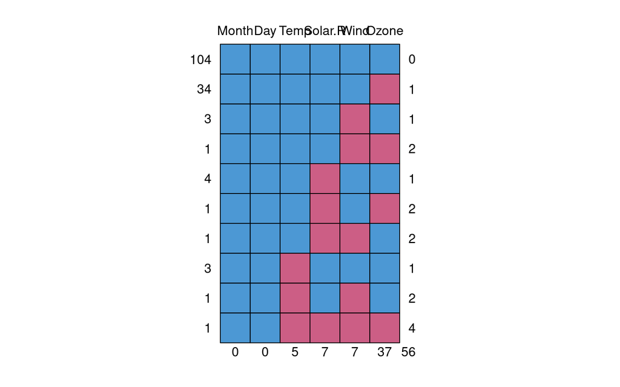

```r
md.pattern(data)
```

Month Day Temp Solar.R Wind Ozone  
104 1 1 1 1 1 1 0 34 1 1 1 1 1 0 1 3 1 1 1 1 0 1 1 1 1 1 1 1 0 0 2 4 1 1 1 0 1 1 1 1 1 1 1 0 1 0 2 1 1 1 1 0 0 1 2 3 1 1 0 1 1 1 1 1 1 1 0 1 0 1 2 1 1 1 0 0 0 0 4 0 0 5 7 7 37 56

## Multiple-Imputation

```r
library(mice)
set.seed(1234)
t <- data.table(id=1:10
              , var1=factor(sample(c("A", "B", "C", NA), 10, replace=TRUE), levels=c("A", "B", "C"))
              , var2=sample(c(1:10, rep(NA, 5)), 10, replace = TRUE)
              , var3=factor(rep(c("Red", "Green"), each=5), levels=c("Red", "Green", "Yellow"))
              , var4=rep(c("Low", "High"), 5)
                )

t %>% prt()
```

| id | var1 | var2 | var3 | var4 |
| --- | --- | --- | --- | --- |
| 1 | NA | 4 | Red | Low |
| 2 | NA | 2 | Red | High |
| 3 | B | 7 | Red | Low |
| 4 | B | 6 | Red | High |
| 5 | A | 10 | Red | Low |
| 6 | NA | 6 | Green | High |
| 7 | C | NA | Green | Low |
| 8 | A | NA | Green | High |
| 9 | A | 4 | Green | Low |
| 10 | B | NA | Green | High |

```r
ti <- mice(t
         , m=5
         , maxit = 50
         , method = 'pmm'
         , seed = 500
         , printFlag = FALSE
           )

tic <- complete(ti, action = "all", include = TRUE)
##tic <- complete(ti, action = 2L, include = TRUE)


tic[[2]] %>% prt()
```

| id | var1 | var2 | var3 | var4 |
| --- | --- | --- | --- | --- |
| 1 | A | 4 | Red | Low |
| 2 | A | 2 | Red | High |
| 3 | B | 7 | Red | Low |
| 4 | B | 6 | Red | High |
| 5 | A | 10 | Red | Low |
| 6 | B | 6 | Green | High |
| 7 | C | 6 | Green | Low |
| 8 | A | 6 | Green | High |
| 9 | A | 4 | Green | Low |
| 10 | B | 6 | Green | High |

## VIM package

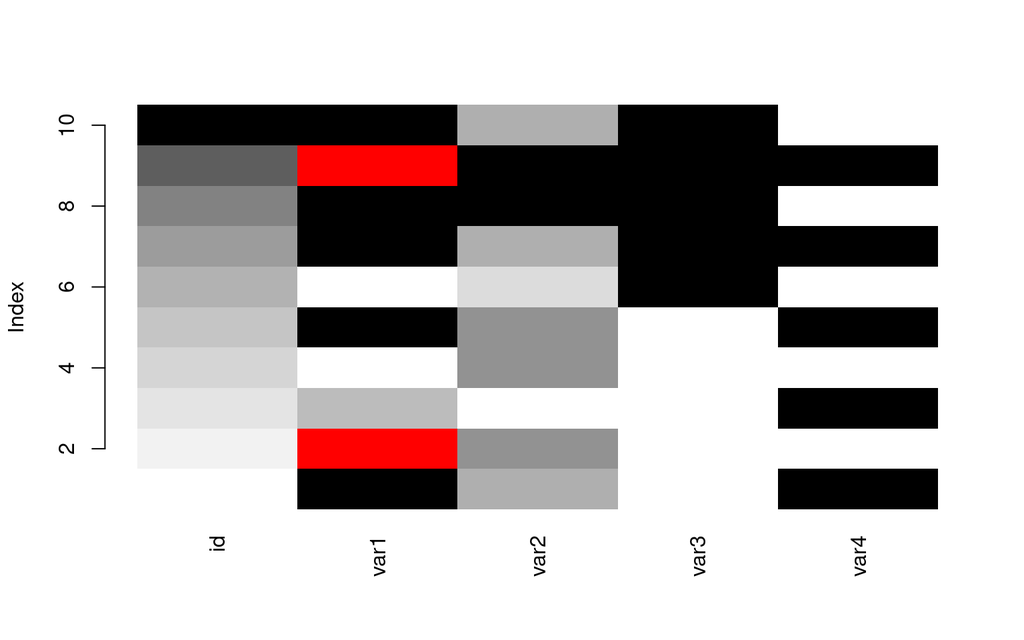

```r
library(VIM)
t <- data.table(id=1:10
                , var1=factor(sample(c("A", "B", "C", NA), 10, replace=TRUE), levels=c("A", "B", "C"))
              , var2=sample(c(1:10, NA), 10, replace = TRUE)
              , var3=factor(rep(c("Red", "Green"), each=5), levels=c("Red", "Green", "Yellow"))
              , var4=rep(c("Low", "High"), 5)
                )

matrixplot(t, sortby = c('id'))
```